# Viñeta paquete mmotaF y anaStatsUEB

[figure not shown]

[figure not shown]

- 1 **Neteja de dades**
  - 1.1 var_to_num (anaStasUEB)
  - 1.2 as.character.ueb (anaStasUEB)
  - 1.3 factor_ueb (anaStasUEB)
  - 1.4 message_ueb (anaStasUEB)
  - 1.5 desc_changes (anaStasUEB)
  - 1.6 date.create (mmotaF)
  - 1.7 NAperc (mmotaF)
  - 1.8 extract_names (mmotaF)
- 2 **Codebook**
  - 2.1 desc_data (anaStatsUEB)
- 3 **Anàlisi de dades**
  - 3.1 **Exploratorio**
  - 3.2 **Modelización**
  - 3.3 **Supervivencia**
  - 3.4 **Test diagnósticos**
  - 3.5 **Otras funcionalidades**
- 4 **En desuso**
  - 4.1 Neteja dades
  - 4.2 Anàlisi de dades
  - 4.3 [freq_table (mmotaF)]
  - 4.4 [summaryCG (anaStatsUEB)]
  - 4.5 [chisq.test2 (mmotaF)]
  - 4.6 [select.varCG (mmotaF)]
  - 4.7 [set.var.labels (mmotaF)]

quadres de colors

# 1 **Neteja de dades**

## 1.1 var_to_num (anaStasUEB)

Convierte datos de texto a numéricos, limpiando formatos como %, , y patrones personalizados (pat → rep).

- Genera advertencias si hay valores que no pudieron convertirse.
- Mantiene un registro de los cambios mediante desc_changes().

**Transformar variable a numérica.**

```r
dat %<>% mutate(followup_time = var_to_num(followup_time))
list_changes[[length(list_changes)]]
```

[1] “ Los valores ‘ongoing’ de la variable ‘followup_time’ han sido considerados datos faltantes ”

**Transformar variable a numérica, reemplazo valores.**

En este ejemplo se muestra la transformación de una variables carácter a numérica reemplazando valores específicos.

```r
tail(dat$blood_pressure)
## blood_pressureHMISClabel
## [1] "112.819698452681" "110.433986098349" "121.551310602619" "138.934475388925"
## [5] "104.635513329502" "118.514948114264"

dat %<>% mutate(blood_pressure = var_to_num(x = blood_pressure,
                                            pat = c("104.635513329502","118.514948114264"),
                                            rep = c(NA,118)))
tail(dat$blood_pressure)
## blood_pressureHMISClabel
## [1] 112.8197 110.4340 121.5513 138.9345       NA 118.0000
```

**Transformación múltiple**

La siguiente función realiza la conversión a tipo numérico de múltiples variables simultáneamente.

```r
var_num <- names(dat %>% select(bmi,cholesterol,quality_of_life))
dat %<>% mutate_at(vars(var_num), var_to_num)
```

Mostramos registro de cambios

```r
list_changes %>%   walk(~ cat(.x, "\n"))
```

- Los valores ‘ongoing’ de la variable ‘followup_time’ han sido considerados datos faltantes
- Los valores ‘high’, ‘104.635513329502’ de la variable ‘blood_pressure’ han sido considerados datos faltantes
- Los valores ‘obese’ de la variable ‘bmi’ han sido considerados datos faltantes
- Los valores ‘elevated’ de la variable ‘cholesterol’ han sido considerados datos faltantes
- Los valores ‘good’ de la variable ‘quality_of_life’ han sido considerados datos faltantes

## 1.2 as.character.ueb (anaStasUEB)

Convierte cualquier tipo de dato a carácter conservando la etiqueta Hmisc::label

```r
head(dat$patient_id)
## patient_idHMISClabel
## [1] 1 2 3 4 5 6
dat %<>% mutate(patient_id = as.character.ueb(patient_id))
head(dat$patient_id)
## patient_idHMISClabel
## [1] "1" "2" "3" "4" "5" "6"
```

## 1.3 factor_ueb (anaStasUEB)

convierte un vector x en un factor, con la posibilidad de personalizar los niveles y las etiquetas. La función devuelve el factor modificado, manteniendo la etiqueta original si existía. Los parámetros de entrada que se pueden necesitar son:

- **levs**: Niveles que se deben asignar al factor.  
- **labs**: Etiquetas que se asignan a los niveles del factor.  
- **del.empty.val**: Si es `TRUE`, elimina los niveles vacíos del factor.  
- **name.var**: El nombre de la variable. Si no se proporciona, se toma de la variable propia.  
- **write_changes**: Por defecto es `TRUE`, escribe los cambios realizados.

- **Transformación de distintas variables a factor**: Seleccionamos todas las variables que queremos transformar y usando la función propia factor_ueb.

```r
var_fac <- names(dat %>% select(treatment, hospital,sex))
dat[,var_fac] <- lapply(dat[,var_fac], function(x) factor_ueb(x, name.var = names(dat[,var_fac])[parent.frame()$i[]]))
```

- **Asignación de etiquetas**: Cuando una variable tiene formato númerico es necesario indicar a cada uno de los niveles una etiqueta.

```r
table(dat$smoker)
```

```
##
##   0   1
## 484 516
```

```r
dat %<>% mutate(smoker = factor_ueb(smoker, levs = c(0:1),labs = c("No", "Sí")))

table(dat$smoker)
```

```
##
##  No  Sí
## 484 516
```

- **Asignación de etiquetas múltiple**

La siguiente función realiza la asignación de etiquetas de múltiples variables simultáneamente.

```r
var_sino <- names(dat %>% select(event, hipertensio))
dat[,var_sino] <- lapply(dat[,var_sino], function(x) factor_ueb(x, levs = c(0,1), labs = c("NoRevisar" ,"SiRevisar"),
  name.var = names(dat[,var_sino])[parent.frame()$i[]]))
```

Mostramos registro de cambios

```r
list_changes %>%   walk(~ cat(.x, "\n"))
```

- Para la variable **smoker**, los valores numéricos originales (‘0’, ‘1’) fueron recodificados como ‘No’, ‘Sí’ respectivamente, para facilitar la interpretación.
- Para la variable **event**, los valores numéricos originales (‘0’, ‘1’) fueron recodificados como ‘NoRevisar’, ‘SiRevisar’ respectivamente, para facilitar la interpretación.
- Para la variable **hipertensio**, los valores numéricos originales (‘0’, ‘1’) fueron recodificados como ‘NoRevisar’, ‘SiRevisar’ respectivamente, para facilitar la interpretación.
- **Reordenar etiquetas**: Cuando se quieren reordenar los niveles de la variable

```r
table(dat$hospital)
```

```
##
## Hospital 1 Hospital 2    Unknown
##        324        349        327
```

```r
dat %<>% mutate(hospital = factor_ueb(hospital,labs = c("Hospital 2", "Hospital 1",  "Unknown")))
table(dat$hospital)
```

```
##
## Hospital 2 Hospital 1    Unknown
##        349        324        327
```

- **REasignación de etiquetas**: En algunos casos una misma etiqueta clínica viene con distintas escrituras. P.e Sí Si. Reasignamos categorías y verificamos que no hemos perdido información

```r
table(dat$diabetes)
```

```
##
##    0    1 24.3    N   No    Y  Yes
##   71  430   79   62   64  118  176
```

```r
dat %<>% mutate(diabetes = factor_ueb(diabetes, levs = c("N",  "1", "0" ,"Y" ,"No","Yes"),
                                                labs = c("No", "Sí","No","Sí","No","Sí")))
table(dat$diabetes)
```

```
##
##  No  Sí
## 197 724
```

```r
list_changes[[length(list_changes)]]
```

[1] “ Para la variable **diabetes**, los valores numéricos originales (‘N’, ‘1’, ‘0’, ‘Y’, ‘No’, ‘Yes’) fueron recodificados como ‘No’, ‘Sí’, ‘No’, ‘Sí’, ‘No’, ‘Sí’ respectivamente, para facilitar la interpretación. ”

## 1.4 message_ueb (anaStasUEB)

Imprimir mensajes en la consola con formato HTML de color. Es necesario indicar en las opciones del chunk results = ‘asis’

```r
message_ueb("Mensaje de prueba de color verde", col = "#009933")
```

Mensaje de prueba de color verde

## 1.5 desc_changes (anaStasUEB)

En el proceso de análisis de datos, es común necesitar modificar variables o realizar correcciones sobre ellas. Esta función permite mantener un registro detallado de estos cambios y facilitar su verificación por parte del equipo investigador.

- **Funcionamiento**: Almacena una lista acumulativa de mensajes en el entorno de R.
- **Integración**: Las funciones propias var_to_num y factor_ueb incorporan automáticamente esta funcionalidad.

**Se le puede cambiar el color al texto con el parámetro col.**

Para registrar información sobre los cambios realizados, se utiliza de la siguiente manera:

```r
var_sino <- c("diabetes","event")
```

```r
desc_changes(paste0("Los valores, 0 y 1 se han considerado 'No' y 'Si' respectivamente para las variables: ", paste(var_sino,collapse = ", ") ))
desc_changes("Las muestras 1 y 2 se han eliminado del estudio ", col = "green")
```

Para mostrar la lista formateada en HTML en el documento final, se debe utilizar el siguiente código:

```r
list_changes %>%   walk(~ cat(.x, "\n"))
```

- Para la variable **smoker**, los valores numéricos originales (‘0’, ‘1’) fueron recodificados como ‘No’, ‘Sí’ respectivamente, para facilitar la interpretación.
- Para la variable **event**, los valores numéricos originales (‘0’, ‘1’) fueron recodificados como ‘NoRevisar’, ‘SiRevisar’ respectivamente, para facilitar la interpretación.
- Para la variable **hipertensio**, los valores numéricos originales (‘0’, ‘1’) fueron recodificados como ‘NoRevisar’, ‘SiRevisar’ respectivamente, para facilitar la interpretación.
- Los individuos con valor ‘24.3’ para la variable diabetes han sido considerados NA
- Para la variable **diabetes**, los valores numéricos originales (‘N’, ‘1’, ‘0’, ‘Y’, ‘No’, ‘Yes’) fueron recodificados como ‘No’, ‘Sí’, ‘No’, ‘Sí’, ‘No’, ‘Sí’ respectivamente, para facilitar la interpretación.
- Los valores, 0 y 1 se han considerado ‘No’ y ‘Si’ respectivamente para las variables: diabetes, event
- Las muestras 1 y 2 se han eliminado del estudio

## 1.6 date.create (mmotaF)

Convierte tres vectores dia, mes, año en un fechas. En el caso de que falte el mes y o el día se indica el 6 y 15 respectivamente.

**La funcionalidad especial respecto a la función lubridate::make_create es que imputa los valores de dia y mes faltantes**

```r
day <- c(NA, NA, NA, 12, 20, NA, NA, NA, 19, NA, 25)
month <- c(NA, NA, 12, 7, 4, NA, 1, NA, 11, NA, 2)
year <- c(2000, NA, 2003, 2012, 2012, 1991, 2013, 2008, 2007, 1994, 2011)
date.create(d = day, m = month, y = year)
```

```
##  [1] "2000-06-15" NA           "2003-12-15" "2012-07-12" "2012-04-20"
##  [6] "1991-06-15" "2013-01-15" "2008-06-15" "2007-11-19" "1994-06-15"
## [11] "2011-02-25"
```

## 1.7 NAperc (mmotaF)

Analiza el porcentaje de datos faltantes por columna en un conjunto de datos.

Esta función devuelve:

- perc: los porcentajes de valores faltantes para cada variable.
- var: un vector con los nombres de las variables que cumplen el criterio de datos faltantes

**Se puede modificar el parámetro maxNA [0-100], para indicar el porcentaje máximo de datos faltantes aceptable**

```r
var_na <- NAperc(dat, maxNA = 90)
#dat %<>% select(-var_na$var) ## De esta forma se pueden eliminar las variables de la base de datos
```

## 1.8 extract_names (mmotaF)

Busca coincidencias entre dos vectores, en este caso ch2clean y var_orig, y elimina lo que no está en var_orig.

Es útil para formatear salidas de modelos. Actualmente se usa para aislar las variables seleccionadas en un modelo Lasso

```r
ch2clean <- c("otras_drogasSí",   "svp_ostomiaSí"  ,     "destino_al_altaCSS" , "localesSí"  ,
"fractura_luxacionSí", "edad"  ,   "minutos_cirugia"  ,   "fijacion_externaSi" )
var_orig <- c("variable1", "variable2" ,"otras_drogas" ,   "sexo", "hipertension",  "svp_ostomia"  ,     "destino_al_alta" ,  "locales"  ,
 "fractura_luxacion", "edad"    ,          "minutos_cirugia" ,  "fijacion_externa" )
extract_names (ch2clean, var_orig)
```

```
## [1] "otras_drogas"      "svp_ostomia"       "destino_al_alta"
## [4] "locales"           "fractura_luxacion" "edad"
## [7] "minutos_cirugia"   "fijacion_externa"
```

# 2 **Codebook**

## 2.1 desc_data (anaStatsUEB)

Esta función es útil para realizar un análisis exploratorio inicial de un conjunto de datos, proporcionando una visión general rápida de la estructura y calidad de los datos. **Genera un resumen detallado en html o latex de un conjunto de datos.**

- **Genérico**: Proporciona información sobre el número de variables y observaciones en el conjunto de datos.
- **Individual**: Muetra para cada variable : Nombre de la variable, Tipo de datos, Descripción (si está disponible), Rango de valores para variables numéricas o niveles para factores, Número y porcentaje de casos válidos y valores faltantes

Parámetros personalizables:

- **maxlev**[numero]: Permite personalizar el número máximo de niveles a mostrar para variables categóricas. Se mostraran en rojo.
- **maxNA**[1-100]: Permite establecer un umbral para resaltar variables con un alto porcentaje de valores faltantes. Se mostraran en rojo.
- **remove_cols**[TRUE/FALSE]: Puede eliminar columnas vacías del conjunto de datos

Ofrece opciones de formato[format: html o latex, df:TRUE/FALSE] como tamaño de fuente[size] y título [caption] de la tabla.

```r
desc_data(data = dat,maxlev = 4, maxNA = 80, remove_cols = F,)
```

Table 2.1: Summary Data. N variables: 15. N observaciones: 1000 Max level: 4. Max NA: 80%

|  | Variable | Type | Description | [Min,Max] or Levels | Valid cases, n (%) Missings, n (%) |
| --- | --- | --- | --- | --- | --- |
| patient_id | patient_id | character | patient_idHMISClabel | - | 1000 (100%) 0 (0%) |
| age | age | numeric | ageHMISClabel | [7.85337981559188, 98.6155990241361] | 1000 (100%) 0 (0%) |
| sex | sex | factor | sexHMISClabel | N LEVELS = 7 1 : 2 : f 3 : F 4 : Female | 1000 (100%) 0 (0%) |
| bmi | bmi | numeric | bmiHMISClabel | [0, 100] | 998 (99.8%) 2 (0.2%) |
| smoker | smoker | factor | smokerHMISClabel | N LEVELS = 2 1 : No 2 : Sí | 1000 (100%) 0 (0%) |
| diabetes | diabetes | factor | diabetesHMISClabel | N LEVELS = 2 1 : No 2 : Sí | 921 (92.1%) 79 (7.9%) |
| hipertensio | hipertensio | factor | hipertensioHMISClabel | N LEVELS = 2 1 : NoRevisar 2 : SiRevisar | 1000 (100%) 0 (0%) |
| blood_pressure | blood_pressure | numeric | blood_pressureHMISClabel | [0, 300] | 994 (99.4%) 6 (0.6%) |
| cholesterol | cholesterol | numeric | cholesterolHMISClabel | [0, 1000] | 992 (99.2%) 8 (0.8%) |
| treatment | treatment | factor | treatmentHMISClabel | N LEVELS = 3 1 : A 2 : B 3 : C | 1000 (100%) 0 (0%) |
| hospital | hospital | factor | hospitalHMISClabel | N LEVELS = 3 1 : Hospital 2 2 : Hospital 1 3 : Unknown | 1000 (100%) 0 (0%) |
| followup_time | followup_time | numeric | followup_timeHMISClabel | [-10, 100] | 996 (99.6%) 4 (0.4%) |
| event | event | factor | eventHMISClabel | N LEVELS = 2 1 : NoRevisar 2 : SiRevisar | 1000 (100%) 0 (0%) |
| quality_of_life | quality_of_life | numeric | quality_of_lifeHMISClabel | [-10, 118.266122075714] | 995 (99.5%) 5 (0.5%) |
| patogeno | patogeno | numeric | patogenoHMISClabel | [1, 1] | 50 (5%) 950 (95%) |

# 3 **Anàlisi de dades**

## 3.1 **Exploratorio**

### 3.1.1 desc_group (anaStatsUEB)

Esta función realiza un resumen numérico de los datos. Para las variables **categóricas**, calcula las frecuencias (totales y en porcentaje entre paréntesis) y el intervalo de confianza exacto al 95%. Para las variables **contínuas** calcula la media y la desviación típica -mean(sd)- junto al intervalo de confianza para la media al 95% -IC[,] - y la mediana y el rango intercuartílico, median[IQR].

Se puede realizar de forma univariada o comparando grupos.

Los parámetros personalizables son:

- **method**: puede ser paramétrico (‘param’) o no paramétrico (‘non-param’). Por defecto, non-param
- **font_size**: Tamaño de fuente de la tabla. Por defecto, 13.
- **byrow**: Cómo se calculan los porcentajes en variables categóricas: por filas (TRUE), por columnas (FALSE). Por defectp,FALSE.
- **width_lev**: Ancho máximo de las columnas de la tabla. Por defecto, 8em.
- **pval_cut**: Punto de corte para resaltar valores p en la tabla. Por defecto, 0.05.
- **show.pval**: Muestra la columna con el p-valor. Por defecto, TRUE
- **show.pval.adj**: Muestra la columna con el p-valor ajustado. Por defecto, FALSE.
- **show.n**: Muestra la columna con la n total. Por defecto, TRUE
- **show.all**: Muestra la columna con el resumen sin tener en cuenta el grupo. Por defecto, TRUE.
- **show.stat**: Muestra la columna con el valor estadístico. Por defecto, FALSE.
- **caption**: Título o descripción de la tabla.
- **paired**: Indica si los datos son apareados. Por defecto, FALSE.
- **idvar**: Nombre de la variable identificadora.

Retorna distintos objetos:

- **$covariates**: nombre de todas las variables descritas en el análisis
- **$df_all**: data.frame con los resultados
- **$results**: resultados formateados en html.
- **$group**[si hay comparación de grupos] : nombre de la variable grupo. En el caso de que la haya
- **$selVar**[si hay comparación de grupos]: nombre de las variables analizadas que superan el umbral de p-valor establecido.
- **$pvalues**[si hay comparación de grupos]: vector con los pvalores para cada una de las variables analizadas.

**Univariado**

```r
res_uni <- desc_group(dat,covariates = names(dat %>% select(age,treatment,diabetes,quality_of_life)) )
res_uni$res
```

Table 3.1: Summary statistics table

| variable | levels | ALL | n |
| --- | --- | --- | --- |
| ageHMISClabel<sub>2</sub> |  | 1000 52.8 (15.1) CI[51.8;53.7] 52.8 [43.3,62.5] | 1000 |
| diabetesHMISClabel<sub>1</sub> | No | 197 (21.4%) [18.8; 24.2] | 921 |
|  | Sí | 724 (78.6%) [75.8; 81.2] |  |
| treatmentHMISClabel<sub>1</sub> | A | 357 (35.7%) [32.7; 38.8] | 1000 |
|  | B | 343 (34.3%) [31.4; 37.3] |  |
|  | C | 300 (30%) [27.2; 32.9] |  |
| quality_of_lifeHMISClabel<sub>2</sub> |  | 995 69.8 (15.2) CI[68.9;70.8] 70.1 [59.2,79.3] | 995 |

* 1: n(%) [Exact CI]  
† 2: N mean(sd) [CI95% mean] median[IQR]

**Comparación grupos**

Muestra las características de los participantes divididos según el grupo. Además de los estadísticos descritos previamente se ha realizado un test de comparación entre grupos. En el caso de que la variable fila sea cuantitativa se realiza una prueba Kruskal-Wallis o U de Mann Whitney según correspondar. Para las variables categóricas se ha realizado una prueba chi-cuadrado o la prueba exacta de Fisher cuando las frecuencias esperadas son inferiores a 5 en algun caso.

```r
res_comp <- desc_group(dat,
                       covariates = names(dat %>% select(age,treatment,patogeno,diabetes,quality_of_life)) ,
                       group = "smoker",
                       byrow = F,
                       show.pval = T,show.pval.adj = F,show.all = T, show.n = T)
res_comp$res
```

Table 3.2: Summary of results by groups of smokerHMISClabel

| variable | levels | No 484 (48.4%) | Sí 516 (51.6%) | ALL | p.value | n |
| --- | --- | --- | --- | --- | --- | --- |
| ageHMISClabel<sub>2</sub> |  | 484 50.5 (15.2) CI[49.1; 51.9] 50.6 [40.1, 60.8] | 516 54.9 (14.7) CI[53.6; 56.2] 54.6 [45.8, 63.8] | 1000 52.8 (15.1) CI[51.8;53.7] 52.8 [43.3,62.5] | <0.001 | 1000 |
| diabetesHMISClabel<sub>1</sub> | No | 197 (48.6%) CI[43.7; 53.6] | 0 (0%) CI[0; 0.7] | 197 (21.4%) [18.8; 24.2] | <0.001 | 921 |
|  | Sí | 208 (51.4%) CI[46.4; 56.3] | 516 (100%) CI[99.3; 100] | 724 (78.6%) [75.8; 81.2] |  |  |
| treatmentHMISClabel<sub>1</sub> | A | 166 (34.3%) CI[30.1; 38.7] | 191 (37%) CI[32.8; 41.3] | 357 (35.7%) [32.7; 38.8] | 0.647<sup>4</sup> | 1000 |
|  | B | 168 (34.7%) CI[30.5; 39.1] | 175 (33.9%) CI[29.8; 38.2] | 343 (34.3%) [31.4; 37.3] |  |  |
|  | C | 150 (31%) CI[26.9; 35.3] | 150 (29.1%) CI[25.2; 33.2] | 300 (30%) [27.2; 32.9] |  |  |
| quality_of_lifeHMISClabel<sub>2</sub> |  | 480 69.4 (15.1) CI[68; 70.7] 69.7 [59.1, 78.5] | 515 70.2 (15.3) CI[68.9; 71.5] 70.4 [59.6, 80.1] | 995 69.8 (15.2) CI[68.9;70.8] 70.1 [59.2,79.3] | 0.35 | 995 |
| patogenoHMISClabel<sub>2</sub> |  | 20 1 (0) CI[1; 1] 1 [1, 1] | 30 1 (0) CI[1; 1] 1 [1, 1] | 50 1 (0) CI[1;1] 1 [1,1] |  | 50 |

* 1: by col n(%) [Exact CI] p.value: <sup>4</sup>Chi-squared  
† 2: N mean(sd) [CI95% mean] median[IQR] p.value: Mann–Whitney U

### 3.1.2 desc_numeric (anaStasUEB)

**Extendido**

```r
res_num <- desc_numeric(data = dat,
             covariates =names(dat %>% select(smoker,treatment,diabetes,quality_of_life)),
             y = "age")
res_num$results
```

Table 3.3: Summary of results for age

| levels | summary | p.value | n |
| --- | --- | --- | --- |
| **smokerHMISClabel** |  |  |  |
| No | 484 50.5 (15.2) CI[49.1; 51.9] 50.6 [40.1, 60.8] | <0.001 | 1000 |
| Sí | 516 54.9 (14.7) CI[53.6; 56.2] 54.6 [45.8, 63.8] |  |  |
| ALL | 1000 52.8 (15.1) CI[51.8;53.7] 52.8 [43.3,62.5] |  |  |
| **diabetesHMISClabel** |  |  |  |
| No | 197 51.3 (14.8) CI[49.2; 53.4] 52.2 [40.1, 61.7] | 0.274 | 921 |
| Sí | 724 53.2 (15.1) CI[52.1; 54.3] 53 [43.7, 62.5] |  |  |
| ALL | 921 52.8 (15.1) CI[51.8;53.7] 52.8 [43.3,62.5] |  |  |
| **treatmentHMISClabel** |  |  |  |
| A | 357 53.4 (15.4) CI[51.8; 55] 53.5 [43.4, 63.3] | 0.37 | 1000 |
| B | 343 52.9 (15) CI[51.3; 54.5] 53.3 [43.8, 62.3] |  |  |
| C | 300 51.9 (14.9) CI[50.2; 53.6] 51.3 [42, 61.5] |  |  |
| ALL | 1000 52.8 (15.1) CI[51.8;53.7] 52.8 [43.3,62.5] |  |  |
| **quality_of_lifeHMISClabel** |  |  |  |
| Pearson Spearman | 0 (-0.1, 0) 0 (-0.1, 0) | 0.7 0.6 | 995 |

* 2: N mean(sd) [CI95% mean] median[IQR] p.value: Mann–Whitney U p.value: Kruska-Wallis  
† Correlation coefficient

**Simple**

```r
res_num <- desc_numeric(data = dat,
             covariates =names(dat %>% select(smoker,treatment,diabetes,quality_of_life)),
             y = "age",show.all = F ,show.n = F,show.pval = F)
res_num$results
```

Table 3.4: Summary of results for age

| levels | summary |
| --- | --- |
| **smokerHMISClabel** |  |
| No | 484 50.5 (15.2) CI[49.1; 51.9] 50.6 [40.1, 60.8] |
| Sí | 516 54.9 (14.7) CI[53.6; 56.2] 54.6 [45.8, 63.8] |
| **diabetesHMISClabel** |  |
| No | 197 51.3 (14.8) CI[49.2; 53.4] 52.2 [40.1, 61.7] |
| Sí | 724 53.2 (15.1) CI[52.1; 54.3] 53 [43.7, 62.5] |
| **treatmentHMISClabel** |  |
| A | 357 53.4 (15.4) CI[51.8; 55] 53.5 [43.4, 63.3] |
| B | 343 52.9 (15) CI[51.3; 54.5] 53.3 [43.8, 62.3] |
| C | 300 51.9 (14.9) CI[50.2; 53.6] 51.3 [42, 61.5] |
| **quality_of_lifeHMISClabel** |  |
| Pearson Spearman | 0 (-0.1, 0) 0 (-0.1, 0) |

* 2: N mean(sd) [CI95% mean] median[IQR] p.value: Mann–Whitney U p.value: Kruska-Wallis  
† Correlation coefficient

### 3.1.3 quickCor (anaStatsUEB)

Esta función calcula la correlación, de Spearman o Pearson, entre dos variables, ofreciendo la flexibilidad de personalizar el análisis según las necesidades del análisis. Permite incluir o excluir un modelo lineal, así como un gráfico de dispersión para visualizar la distribución de los datos.

De forma general se puede personalizar:

- el número de decimales, `nround = 2`
- el tamaño del texto, `cex.main, cex.text`

En el gráfico, se puede personalizar:

- el título, `main = ""`,
- el subtítulo , `sub = ""`,
- la posición de la leyenda `pos = "bottom"`

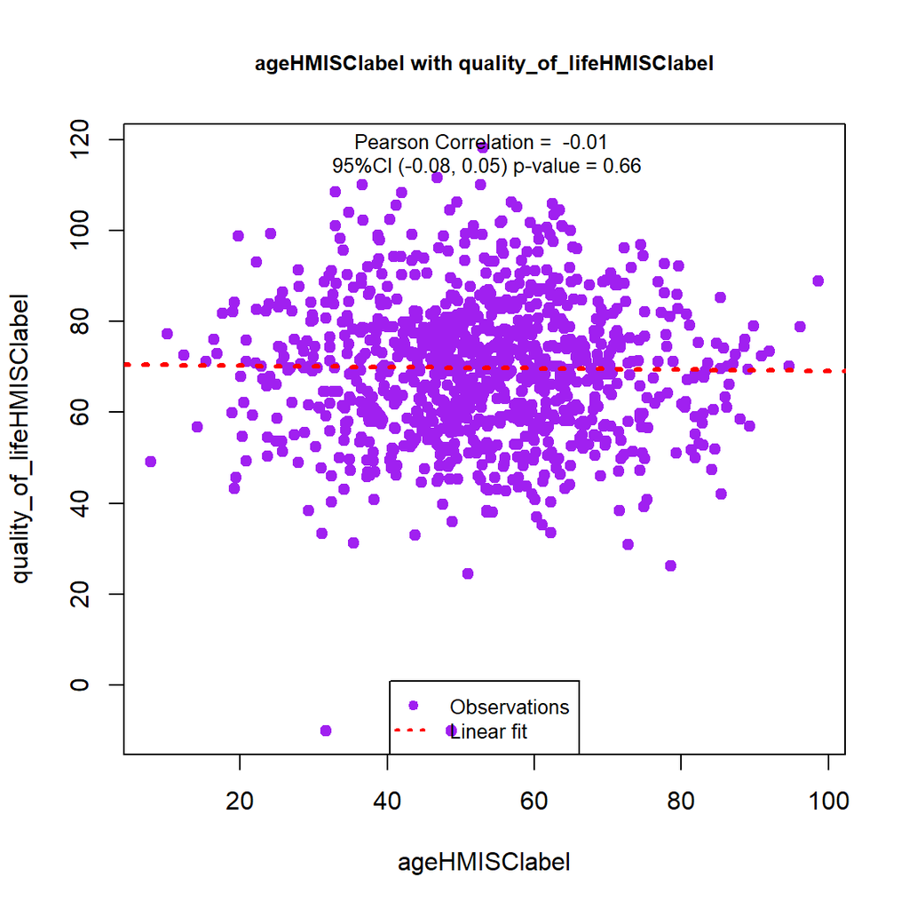

Table 3.5: Correlation age whit quality_of_life .

|  | rho | IC | p-value | n |
| --- | --- | --- | --- | --- |
| Pearson | -0.01 | (-0.08, 0.05) | 0.66 | 995 |
| Spearman | -0.02 | (-0.08, 0.05) | 0.63 | 995 |

```r
quickCor(dat, x = "age", y = "quality_of_life",
         pearson = T,
         corplot = T,
         lm.fit = T,
         show.pval = T,
         pos = "bottom",xtab = T,nround = 2,
         show.res = F)
```

### 3.1.4 desc_plot (mmotaF)

Esta función realiza un análisis gráfico para cada una de las variables. Para las variables categóricas realiza un diagrama de barras, donde cada barra indica una categoría y el eje vertical el porcentaje, el recuento absoluto se muestra en cada una de las categorías. Para las variables numéricas realiza un histograma.

Cada gráfico muestra (o puede mostrar) además:

- El tamaño muestral disponible para el gráfico
- El color del histograma, `color`
- El subtitulo, `subtitle`
- El p-valor, `do.test = TRUE`
- El tamaño de las etiquetas. Leyenda, `cex.lg`. Título, `cex.main`, N, `cex.n`. Etiquetas, `cex.lab`
- La orientación de los niveles, `las`
- [Bivariado] Los puntos del boxplot, `bw = T`. Si el número de individuos es superior a 1000 no se muestran. Se puede modificar este valor con el parámetro `bw.n.max`
- Mostrar u ocultar leyenda, frecuencias o n total `show.lg, show.freq, show.n`
- Número de gráficos por página, filas y columnas, `rowcol = c(3, 2)`

**Se puede ejecutar de forma univariada o seleccionando una variable grupo, `y = ""`.**

Los datos se pueden introducir en la función mediante formula, base de datos sin seleccion de variables o indicando covariates y grupo (y).

- **Univariado**

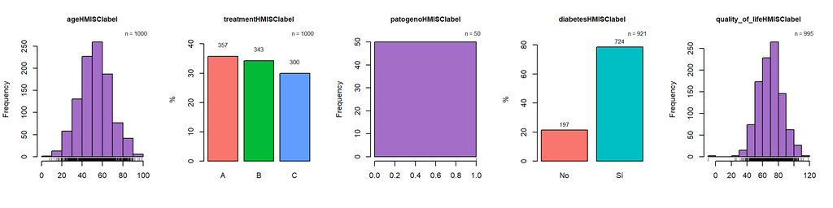

```r
# desc_plot(dat %>% select(age,treatment,patogeno,diabetes,quality_of_life), topdf = F)
desc_plot(dat = dat, covariates = names(dat %>% select(age,treatment,patogeno,diabetes,quality_of_life)),
          topdf = F, rowcol = c(1,5))
```

- **Bivariado**

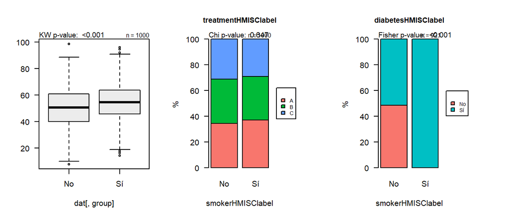

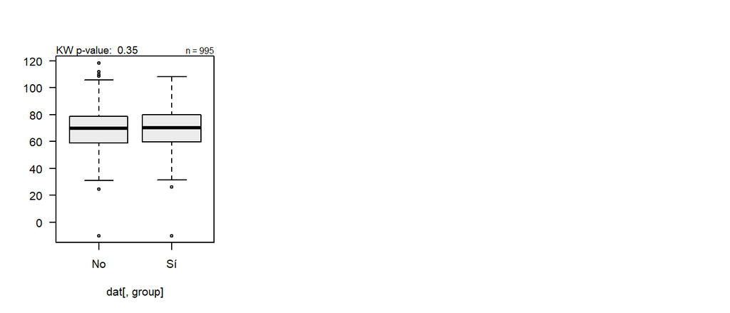

```r
desc_plot(dat = dat,
          covariates = names(dat %>% select(age,treatment,diabetes,quality_of_life)),
          y = "smoker",
          do.test = T,
          bw.n.max = 500,
          show.lg = T, show.freq = T, show.n = T,
          rowcol = c(1, 3),
          las = 1,
          topdf = F)
```

### 3.1.6 boxplot_bw (mmotaF)

PENDENT

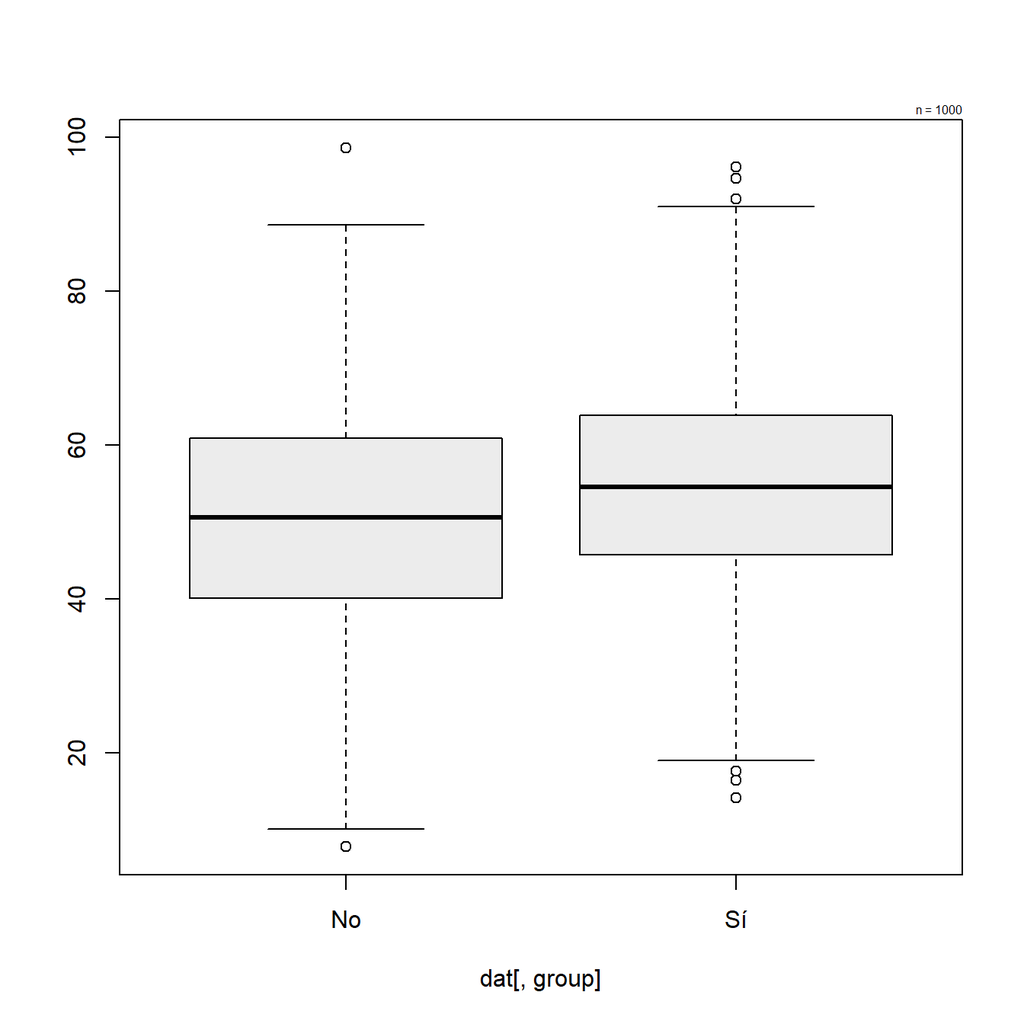

```r
boxplot_bw(y = "age",group = "smoker",dat = dat)
```

### 3.1.7 summary.quali (anaStatsUEB)

Esta funcion realiza un análisis estadistico numérico para una o dos variables cualitativas. Se puede ejecutar de forma univariada o bivariada.

Esta pensada como función intermedia para la función `desc_group` usa esta función para generar una tabla estructurada y fácil de interpretar con múltiples variables.

```r
summary.quali(dat, x = "smoker")
```

```
## $variable
## [1] "smoker"
##
## $methods
## [1] " <font size='1'> 1: n(%) <br> [Exact CI] </font>"
##
## $txt_caption
## [1] " <font size='1'> 1: n(%) <br> [Exact CI] </font>"
##
## $summary
##                        variable levels                           ALL    n
## No smokerHMISClabel<sub>1</sub>     No 484 (48.4%) <br> [45.3; 51.5] 1000
## Sí                                  Sí 516 (51.6%) <br> [48.5; 54.7]
```

```r
summary.quali(dat, x = "hospital", group = "smoker")
```

```
## $rows
## [1] "hospital"
##
## $columns
## [1] "smoker"
##
## $txt_test
## [1] "<font size='1'> <br> p.value: <sup>4</sup>Chi-squared</font>"
##
## $pval
## [1] 0.4027473
##
## $txt_caption
## [1] "Summary of results by groups of smokerHMISClabel <font size='1'> <br> 1: by col <br> n(%) <br> [Exact CI] </font>  <font size='1'> <br> 1: by col <br> n(%) <br> [Exact CI] </font>  <font size='1'> <br> 1: by col <br> n(%) <br> [Exact CI] </font> <font size='1'> <br> p.value: <sup>4</sup>Chi-…
##
## $methods
## [1] " <font size='1'> <br> 1: by col <br> n(%) <br> [Exact CI] </font>"
##
## $summary
##                                  variable     levels
## Hospital 2 hospitalHMISClabel<sub>1</sub> Hospital 2
## Hospital 1                                Hospital 1
## Unknown                                      Unknown
##                                         No                              Sí
## Hospital 2   177 (36.6%) <br> CI[32.3; 41] 172 (33.3%) <br> CI[29.3; 37.6]
## Hospital 1   158 (32.6%) <br> CI[28.5; 37] 166 (32.2%) <br> CI[28.2; 36.4]
## Unknown    149 (30.8%) <br> CI[26.7; 35.1] 178 (34.5%) <br> CI[30.4; 38.8]
##                                      ALL           p.value    n
## Hospital 2 349 (34.9%) <br> [31.9; 37.9] 0.403<sup>4</sup> 1000
## Hospital 1 324 (32.4%) <br> [29.5; 35.4]
## Unknown    327 (32.7%) <br> [29.8; 35.7]
```

### 3.1.8 summary.quanti (anaStatsUEB)

Esta funcion realiza un análisis estadistico numérico para una variable cualitativa y una variable cuantitativa . Se puede ejecutar de forma univariada (cuantitativa) o bivariada.

Esta pensada como función intermedia para la función `desc_group` usa esta función para generar una tabla estructurada y fácil de interpretar con múltiples variables.

```r
summary.quanti(dat, x = "age")
```

```
## $variable
## [1] "age"
##
## $methods
## [1] "<br> <font size='1'> 2: N <br> mean(sd) <br> [CI95% mean] <br> median[IQR] </font>"
##
## $txt_caption
## [1] "<br> <font size='1'> 2: N <br> mean(sd) <br> [CI95% mean] <br> median[IQR] </font>"
##
## $summary
##                    variable
## 1 ageHMISClabel<sub>2</sub>
##                                                              ALL    n
## 1 1000 <br> 52.8 (15.1) <br> CI[51.8;53.7] <br> 52.8 [43.3,62.5] 1000
```

```r
summary.quanti(dat, x = "age", group = "smoker")
```

```
## $rows
## [1] "age"
##
## $txt_test
## [1] "<font size='1'> <br> p.value:  Student's T</font>"
##
## $pval
## [1] 3.727483e-06
##
## $txt_caption
## [1] "Summary of results by groups of smokerHMISClabel<br> <font size='1'> 2: N <br> mean(sd) <br> [CI95% mean] <br> median[IQR] </font>"
##
## $methods
## [1] "<br> <font size='1'> 2: N <br> mean(sd) <br> [CI95% mean] <br> median[IQR] </font>"
##
## $summary
##                                            variable
## ageHMISClabel<sub>2</sub> ageHMISClabel<sub>2</sub>
##                                                                                        No
## ageHMISClabel<sub>2</sub> 484 <br> 50.5 (15.2) <br> CI[49.1; 51.9] <br> 50.6 [40.1, 60.8]
##                                                                                        Sí
## ageHMISClabel<sub>2</sub> 516 <br> 54.9 (14.7) <br> CI[53.6; 56.2] <br> 54.6 [45.8, 63.8]
##                                                                                      ALL
## ageHMISClabel<sub>2</sub> 1000 <br> 52.8 (15.1) <br> CI[51.8;53.7] <br> 52.8 [43.3,62.5]
##                           p.value    n
## ageHMISClabel<sub>2</sub>  <0.001 1000
```

## 3.2 **Modelización**

### 3.2.1 desc_mod

Resume y formatea modelos logísticos, lineales, de supervivencia, coxph, binomial negativa y clogit, tanto univariados como multivariados.

```r
mod_glm <- glm(smoker ~age, data = dat,family = "binomial")
mod_lm <- lm(age ~quality_of_life, data = dat)

desc_mod(mod_glm,xtab = T,digits = 2)
```

Table 3.6: Model summary

| Variable | Odds Ratio | CI (lower) | CI (upper) | Pr(>\|z\|) | N |
| --- | --- | --- | --- | --- | --- |
| age | 1.019957 | 1.011408 | 1.028733 | <0.001 | 1000 |

```r
desc_mod(mod_lm, xtab = T)
```

Table 3.6: Model summary

| Variable | Estimate | CI (lower) | CI (upper) | Pr(>\|t\|) | N |
| --- | --- | --- | --- | --- | --- |
| quality_of_life | -0.0138423 | -0.0754444 | 0.0477597 | 0.659 | 995 |

### 3.2.2 desc_unimods (mmotaF)

Ejecuta uno o muchos modelos para una misma variable respuesta y distintas explicativas. Los modelos son univariados y los formatea en una única tabla.

Se puede ajustar:

- El tipo de modelo: lineales (“linear”) o logísticos (“logistic”), parámetro `type`
- Añadir un caption, `caption`
- Mostrar o ocultar la n total, `show.n`

En los outputs se puede recuperar el modelo original en `$mod$nombrevariable`

```r
### Logistica
desc_unimods(y = "smoker",
             var2test = names(dat %>% select(age,treatment,diabetes,quality_of_life)),
             data = dat ,
             type = "logistic")
```

$unimod_ci_df vars_label levs Odds Ratio CI (lower) age ageHMISClabel 1.02000e+00 1.010000e+00 treatment: B treatmentHMISClabel : B 9.10000e-01 6.700000e-01 treatment: C treatmentHMISClabel : C 8.70000e-01 6.400000e-01 diabetes: Sí diabetesHMISClabel : Sí 2.86898e+08 1.265686e+95 quality_of_life quality_of_lifeHMISClabel 1.00000e+00 1.000000e+00 CI (upper) Pr(>|z|) N age 1.030000e+00 <0.001 1000 treatment: B 1.220000e+00 0.511 1000 treatment: C 1.180000e+00 0.371 NA diabetes: Sí 2.715461e+92 0.967 921 quality_of_life 1.010000e+00 0.39 995

Call: glm(formula = frml, family = “binomial”, data = data)

Coefficients: (Intercept) age  
-0.97737 0.01976

Degrees of Freedom: 999 Total (i.e. Null); 998 Residual Null Deviance: 1385 Residual Deviance: 1364 AIC: 1368

$mods$treatment

Call: glm(formula = frml, family = “binomial”, data = data)

Coefficients: (Intercept) treatmentB treatmentC  
0.14029 -0.09946 -0.14029

Degrees of Freedom: 999 Total (i.e. Null); 997 Residual Null Deviance: 1385 Residual Deviance: 1384 AIC: 1390

$mods$diabetes

Call: glm(formula = frml, family = “binomial”, data = data)

Coefficients: (Intercept) diabetesSí  
-18.57 19.47

Degrees of Freedom: 920 Total (i.e. Null); 919 Residual (79 observations deleted due to missingness) Null Deviance: 1263 Residual Deviance: 868.4 AIC: 872.4

$mods$quality_of_life

Call: glm(formula = frml, family = “binomial”, data = data)

Coefficients: (Intercept) quality_of_life  
-0.180012 0.003587

Degrees of Freedom: 994 Total (i.e. Null); 993 Residual (5 observations deleted due to missingness) Null Deviance: 1378 Residual Deviance: 1377 AIC: 1381

```r
### linear

desc_unimods(y = "age",
             var2test = names(dat %>% select(treatment,diabetes,quality_of_life)),
             data = dat ,
             type = "linear")
```

$unimod_ci_df vars_label levs Estimate CI (lower) CI (upper) treatment: B treatmentHMISClabel : B -0.51 -2.75 1.73 treatment: C treatmentHMISClabel : C -1.54 -3.86 0.79 diabetes: Sí diabetesHMISClabel : Sí 1.91 -0.46 4.28 quality_of_life quality_of_lifeHMISClabel -0.01 -0.08 0.05 Pr(>|t|) N treatment: B 0.653 1000 treatment: C 0.194 NA diabetes: Sí 0.114 921 quality_of_life 0.659 995

Call: lm(formula = frml, data = data)

Coefficients: (Intercept) treatmentB treatmentC  
53.4114 -0.5133 -1.5358

$mods$diabetes

Call: lm(formula = frml, data = data)

Coefficients: (Intercept) diabetesSí  
51.28 1.91

$mods$quality_of_life

Call: lm(formula = frml, data = data)

Coefficients: (Intercept) quality_of_life  
53.68562 -0.01384

**Univariado**

```r
desc_unimods(y = "smoker",
             var2test = "age",
             data = dat ,
             type = "logistic")
```

$unimod_ci_df vars_label levs Odds Ratio CI (lower) CI (upper) Pr(>|z|) N age ageHMISClabel 1.02 1.01 1.03 <0.001 1000

Call: glm(formula = frml, family = “binomial”, data = data)

Coefficients: (Intercept) age  
-0.97737 0.01976

Degrees of Freedom: 999 Total (i.e. Null); 998 Residual Null Deviance: 1385 Residual Deviance: 1364 AIC: 1368

### 3.2.3 glm.uni (mmotaF)

Esta permite poner una variable de var2match

```r
glm.uni(y = "smoker",
             var2test = names(dat %>% select(age,treatment,diabetes,quality_of_life)),
             data = dat )
```

```
## $unimod_list
## $unimod_list$age
##
## Call:  glm(formula = formula, family = binomial, data = data[complete.cases(data[,
##     y]), ])
##
## Coefficients:
## (Intercept)          age
##    -0.97737      0.01976
##
## Degrees of Freedom: 999 Total (i.e. Null);  998 Residual
## Null Deviance:       1385
## Residual Deviance: 1364  AIC: 1368
##
## $unimod_list$treatment
##
## Call:  glm(formula = formula, family = binomial, data = data[complete.cases(data[,
##     y]), ])
##
## Coefficients:
## (Intercept)   treatmentB   treatmentC
##     0.14029     -0.09946     -0.14029
##
## Degrees of Freedom: 999 Total (i.e. Null);  997 Residual
## Null Deviance:       1385
## Residual Deviance: 1384  AIC: 1390
##
## $unimod_list$diabetes
##
## Call:  glm(formula = formula, family = binomial, data = data[complete.cases(data[,
##     y]), ])
##
## Coefficients:
## (Intercept)   diabetesSí
##      -18.57        19.47
##
## Degrees of Freedom: 920 Total (i.e. Null);  919 Residual
##   (79 observations deleted due to missingness)
## Null Deviance:       1263
## Residual Deviance: 868.4     AIC: 872.4
```

[output cut: 96 more lines]

[output not shown]

### 3.2.4 stepLR (mmotaF)

Construye el mejor modelo de regresion logistica basandose en el AIC y cuyo pvalor al comparar los modelos mediante LRT sea inferior a 0.1, partiendo de ‘x’ variables explicativas.

IMPORTANTE: para la construcción de todos los modelos se tendran en cuenta solo aquellos pacientes que tengan valores para todas las variables indicadas excepto para el final que tendra en cuenta las variables finales.

OUTPUT:

- **modfin**: exporta dos modelos, el final teniendo en cuenta solo aquellos individuos que tienen todos los valores para todas las variables y un segundo modelo que tiene en cuenta todos aquellos individuos que tienen valores para las variables finales.

```r
modfin <- stepLR(VR = 'smoker',
                 varExpl = names(dat %>% select(age,treatment,diabetes,quality_of_life)),
                 data = dat,
                 trace = FALSE )
desc_mod(modfin[[1]],xtab = T)
```

Table 3.7: Model summary

| Variable | Odds Ratio | CI (lower) | CI (upper) | Pr(>\|z\|) | N |
| --- | --- | --- | --- | --- | --- |
| diabetes: Sí | 2.938815e+08 | 4.705409e+92 | 2.558235e+91 | 0.966 | 917 |
| age | 1.027583e+00 | 1.016142e+00 | 1.039480e+00 | <0.001 |  |

```r
desc_mod(modfin[[2]],xtab = T)
```

Table 3.7: Model summary

| Variable | Odds Ratio | CI (lower) | CI (upper) | Pr(>\|z\|) | N |
| --- | --- | --- | --- | --- | --- |
| diabetes: Sí | 2.952882e+08 | 5.987246e+93 | 1.045397e+91 | 0.966 | 921 |
| age | 1.027843e+00 | 1.016418e+00 | 1.039726e+00 | <0.001 |  |

### 3.2.5 desc_lasso (mmotaF)

## 3.3 **Supervivencia**

### 3.3.1 coxPretty (anaStatsUEB)

### 3.3.2 make_surv_table (mmotaF)

### 3.3.3 quickSurv (anaStatsUEB)

### 3.3.4 sumsurv_df (anaStatsUEB)

## 3.4 **Test diagnósticos**

### 3.4.1 diag.test (mmotaF)

### 3.4.2 doROC (mmotaF)

## 3.5 **Otras funcionalidades**

### 3.5.1 makeTransparent (mmotaF)

Toma un color (o varios colores) y un valor de transparencia (alpha), y devuelve el mismo color pero con la transparencia aplicada.

```r
makeTransparent("red", alpha = 0.2)
```

```
## [1] "#FF000033"
```

### 3.5.2 gg_color (mmotaF)

Esta función genera un conjunto de colores utilizando el espacio de color HCL (Hue, Chroma, Luminance). Es comúnmente utilizada para crear paletas de colores que son perceptualmente uniformes, lo que significa que los colores se perciben de manera equilibrada y son adecuados para visualizaciones de datos. ggplot usa estos colores

```r
gg_color(2)
```

```
## [1] "#F8766D" "#00BFC4"
```

```r
gg_color(5)
```

```
## [1] "#F8766D" "#A3A500" "#00BF7D" "#00B0F6" "#E76BF3"
```

### 3.5.3 kable_ueb (anaStatsUEB)

Formatea una tabla o data.frame cualquiera a kable con los institucionales. Se le pueden aplicar todos las funciones que que acepta la función kable.

```r
tab <- table(dat$hospital,dat$treatment)
kable_ueb(tab)
```

|  | A | B | C |
| --- | --- | --- | --- |
| Hospital 2 | 136 | 114 | 99 |
| Hospital 1 | 111 | 122 | 91 |
| Unknown | 110 | 107 | 110 |

```r
kable_ueb(tab) %>% remove_column(2)
```

|  | B | C |
| --- | --- | --- |
| Hospital 2 | 114 | 99 |
| Hospital 1 | 122 | 91 |
| Unknown | 107 | 110 |

# 4 **En desuso**

## 4.1 Neteja dades

### 4.1.1 [re_name (mmotaF)]

Probablemente deprecated. Función previa a descubrir janitor::clean_names

### 4.1.2 [create_dictionary (mmotaF)]

Probablemente deprecated. Función previa a factor_ueb

### 4.1.3 [dictionary_list (mmotaF)]

Probablemente deprecated. Función previa a factor_ueb

### 4.1.4 [recode_factor (mmotaF)]

Probablemente deprecated. Función previa a factor_ueb.

A continuación se muestra un ejemplo de como funciona.

```r
dc_fumador <- create_dictionary(factorDat$Fumador)
table(factorDat$Fumador)
factorDat$Fumador <- recode_factor(dict = dc_fumador, var = factorDat$Fumador)
table(factorDat$Fumador)
```

## 4.2 Anàlisi de dades

## 4.3 [freq_table (mmotaF)]

Probablemente deprecated. Creo que era previo al summary.quali

## 4.4 [summaryCG (anaStatsUEB)]

Probablemente deprecated. Se usaba con el compareGroups.

## 4.5 [chisq.test2 (mmotaF)]

Probablemente deprecated. Se usaba con el compareGroups.

## 4.6 [select.varCG (mmotaF)]

Probablemente deprecated. Se usaba con el compareGroups.

## 4.7 [set.var.labels (mmotaF)]

Probablemente deprecated. Creo que es lo que se usaba antes de `Hmisc::label(dat, self = F) <- lbls`

A work by [UEB](http://www.ueb.vhir.org)  
CONTACT US

[figure not shown]

[figure not shown]

VHIR-UEB-FOR-019v.01